# LDA tutorial

This notebook demonstrates the strengths of Linear Discriminant Analysis (LDA) through a simple study on gender prediction. First, LDA is introduced and illustrated. It is then compared with Quadratic Discriminant Analysis (QDA) and Logistic Regression (LR).

## Read the data

The dataset holds data on weight, height and gender of 10,000 individuals and was taken from https://www.kaggle.com/mustafaali96/weight-height.

```r
life_data <- read.csv("weight-height.csv")

# height in inches, weight in pounds, transform to cm and kg
life_data <- life_data %>%
  mutate(Height = Height * 2.54,
         Weight = life_data$Weight * 0.454,
         Gender = as.factor(Gender))

glimpse(life_data)
```

```
## Rows: 10,000
## Columns: 3
## $ Gender <fct> Male, Male, Male, Male, Male, Male, Male, Male, Male, Male, Mal…
## $ Height <dbl> 187.5714, 174.7060, 188.2397, 182.1967, 177.4998, 170.8227, 174…
## $ Weight <dbl> 109.81968, 73.68895, 96.58435, 99.89928, 93.68281, 69.10432, 83…
```

## Analyse height only

First, consider only the height. Let us see its relationship with gender.

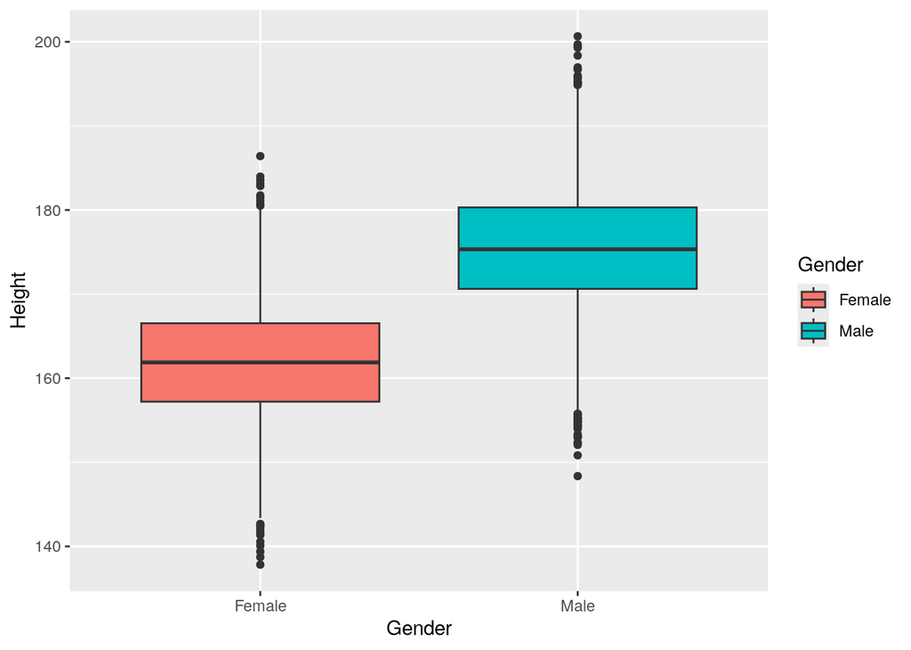

```r
# visualize the data
life_data %>% ggplot(aes(x=Gender, y=Height, fill=Gender)) +
  geom_boxplot()
```

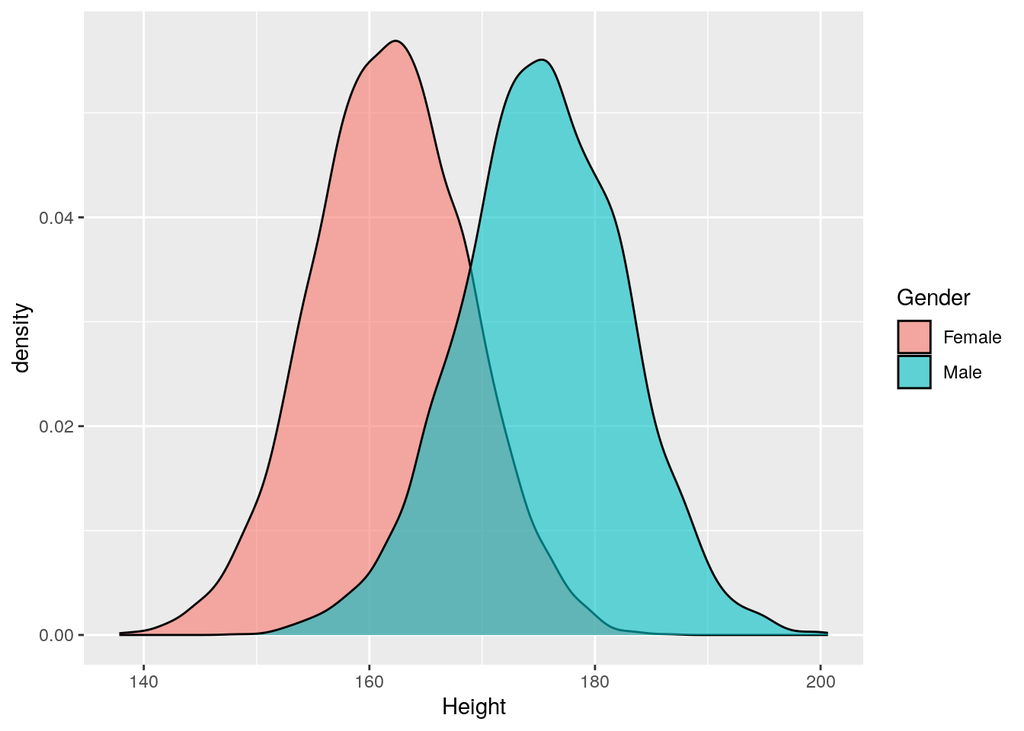

```r
life_data %>% ggplot(aes(x=Height, fill=Gender)) +
  geom_density(alpha=0.6)
```